# Housing Predictions - EDA [Day3]

Divya Reddy

9/26/2019

Load packages

```r
library(dplyr)
```

```r
library(ggplot2)
library(data.table)
```

Set present working directory and load the data

```r
setwd("C:/Users/dreddy/Desktop/HousingData")
housing <- read.csv("./train.csv")
```

Convert data frame to data table

```r
housing <- setDT(housing)
```

Looking at the datatypes of the variables

```r
str(housing)
```

```
## Classes 'data.table' and 'data.frame':   1460 obs. of  81 variables:
##  $ Id           : int  1 2 3 4 5 6 7 8 9 10 ...
##  $ MSSubClass   : int  60 20 60 70 60 50 20 60 50 190 ...
##  $ MSZoning     : Factor w/ 5 levels "C (all)","FV",..: 4 4 4 4 4 4 4 4 5 4 ...
##  $ LotFrontage  : int  65 80 68 60 84 85 75 NA 51 50 ...
##  $ LotArea      : int  8450 9600 11250 9550 14260 14115 10084 10382 6120 7420 ...
##  $ Street       : Factor w/ 2 levels "Grvl","Pave": 2 2 2 2 2 2 2 2 2 2 ...
##  $ Alley        : Factor w/ 2 levels "Grvl","Pave": NA NA NA NA NA NA NA NA NA NA ...
##  $ LotShape     : Factor w/ 4 levels "IR1","IR2","IR3",..: 4 4 1 1 1 1 4 1 4 4 ...
##  $ LandContour  : Factor w/ 4 levels "Bnk","HLS","Low",..: 4 4 4 4 4 4 4 4 4 4 ...
##  $ Utilities    : Factor w/ 2 levels "AllPub","NoSeWa": 1 1 1 1 1 1 1 1 1 1 ...
##  $ LotConfig    : Factor w/ 5 levels "Corner","CulDSac",..: 5 3 5 1 3 5 5 1 5 1 ...
##  $ LandSlope    : Factor w/ 3 levels "Gtl","Mod","Sev": 1 1 1 1 1 1 1 1 1 1 ...
##  $ Neighborhood : Factor w/ 25 levels "Blmngtn","Blueste",..: 6 25 6 7 14 12 21 17 18 4 ...
##  $ Condition1   : Factor w/ 9 levels "Artery","Feedr",..: 3 2 3 3 3 3 3 5 1 1 ...
```

[output cut: 68 more lines]

After looking at the datatypes and going through the data_description.txt, we need to convert the following columns to character datatype

```r
housing$MSSubClass <- as.character(housing$MSSubClass)
housing$YearBuilt <- as.character(housing$YearBuilt)
housing$YearRemodAdd <- as.character(housing$YearRemodAdd)
housing$MoSold <- as.character(housing$MoSold)
housing$YrSold <- as.character(housing$YrSold)
housing$GarageYrBlt <- as.character(housing$GarageYrBlt)
#str(housing)
```

Outliers can be identified by using boxplots, boxplots(IQR) or using Z scores. The boxplot(IQR) method using the 1.5xIQR- Q1 (lower limit) and Q3+ 1.5xIQR (upper limit) to eliminate outliers The z-score value is the measure of how far the data point is from the mean = 0 and SD = 1, i.e., a normal deviation. We consider the z scores between -3 to 3 to eliminate outliers. You can also remove all outliers less than the 5th percentile and greater than the 95th percentile

Plotting graphs for outlier analysis

```r
varlist <- colnames(dplyr::select_if(housing, is.numeric))

plot <- function (varlist) {
   # require(ggplot2)
    ggplot(data = housing, mapping = aes_string(y=varlist))+
            geom_boxplot() + scale_x_discrete(limits=c("0.5", "1"))
}
```

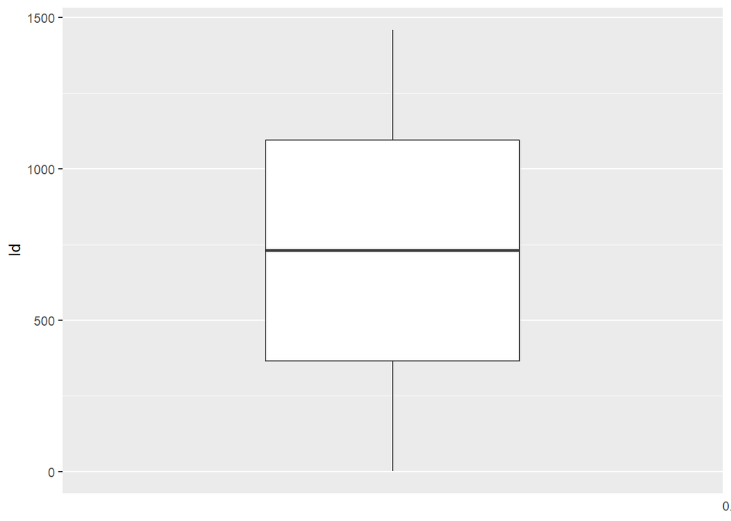

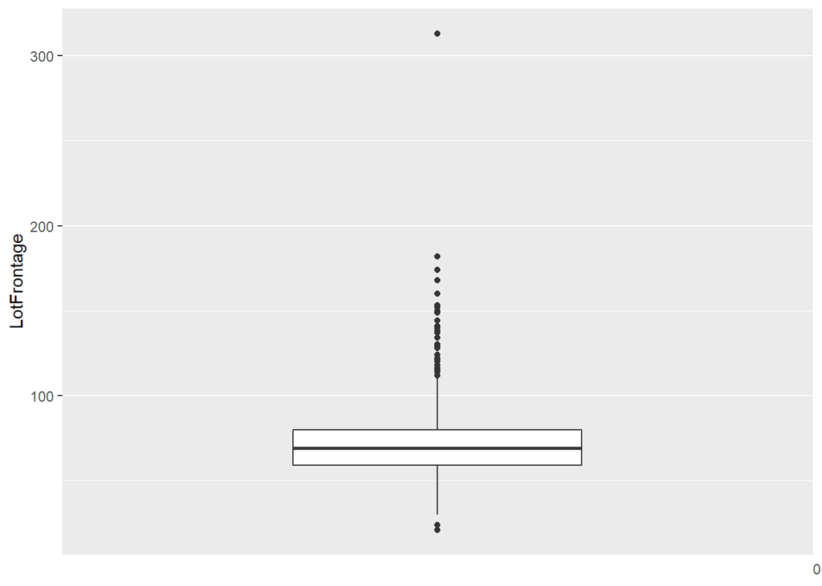

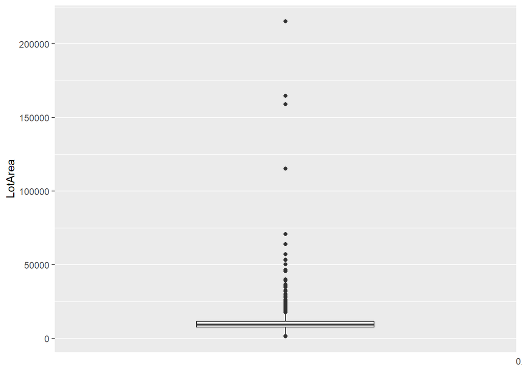

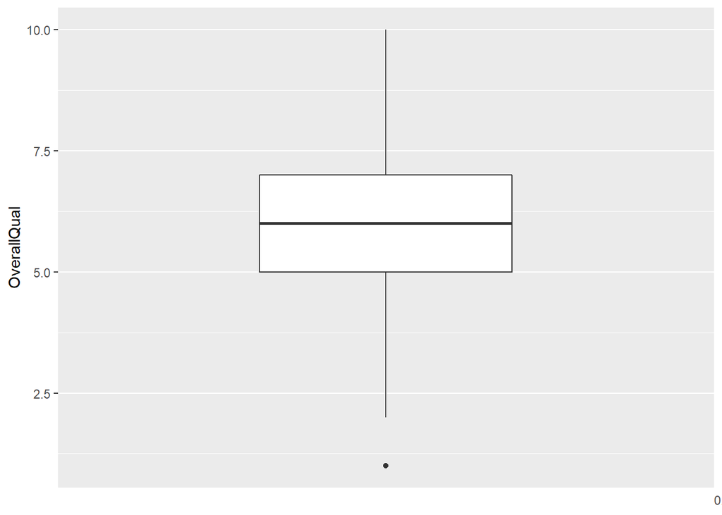

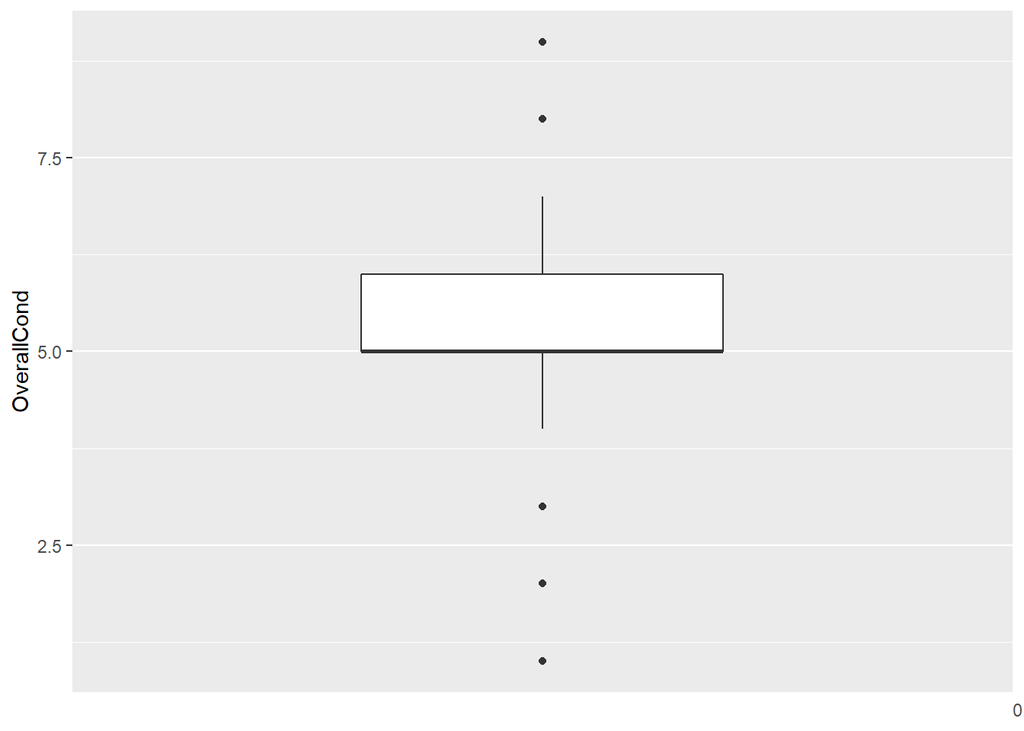

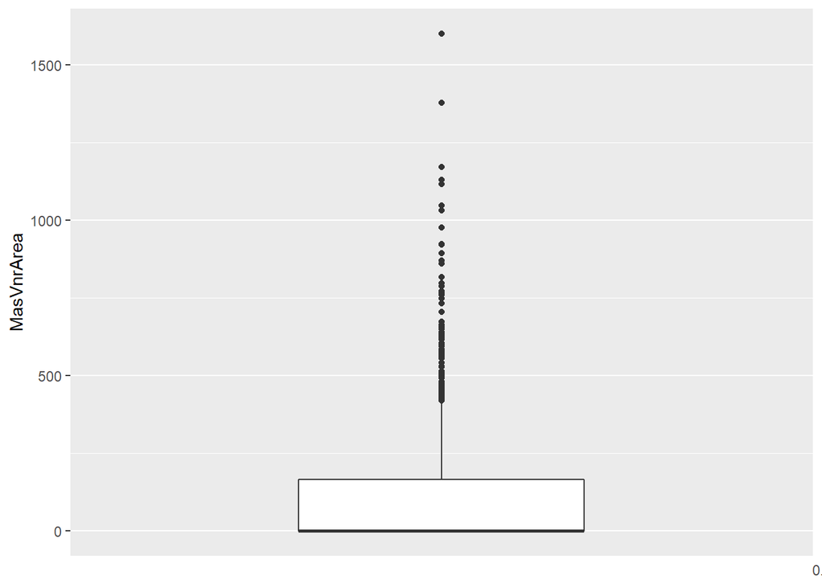

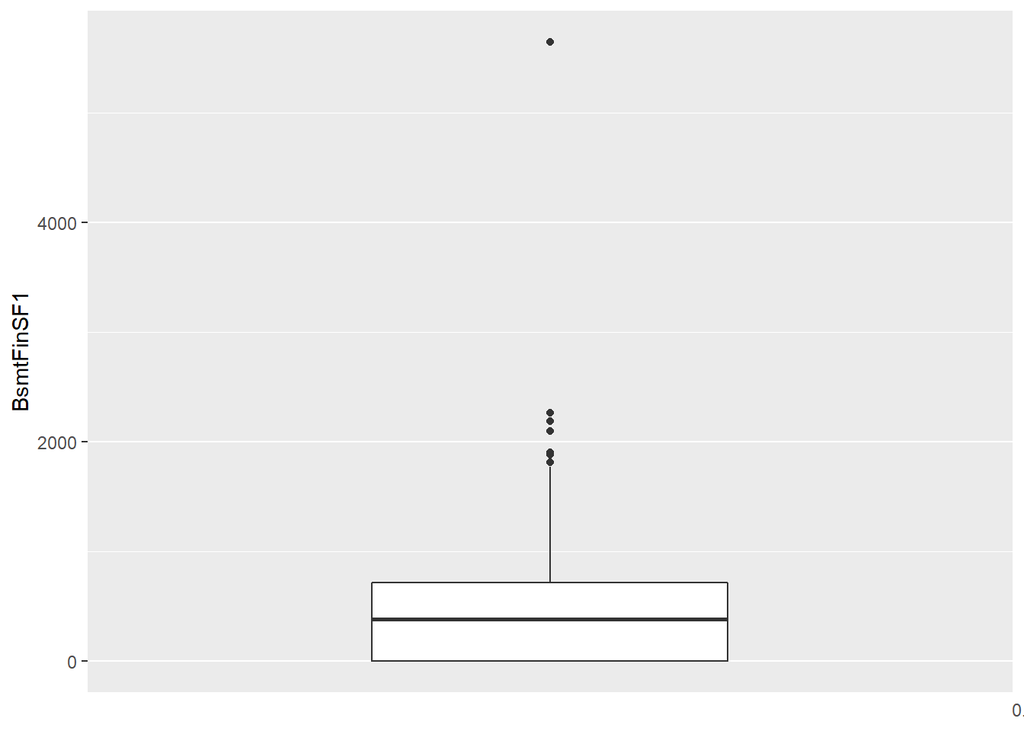

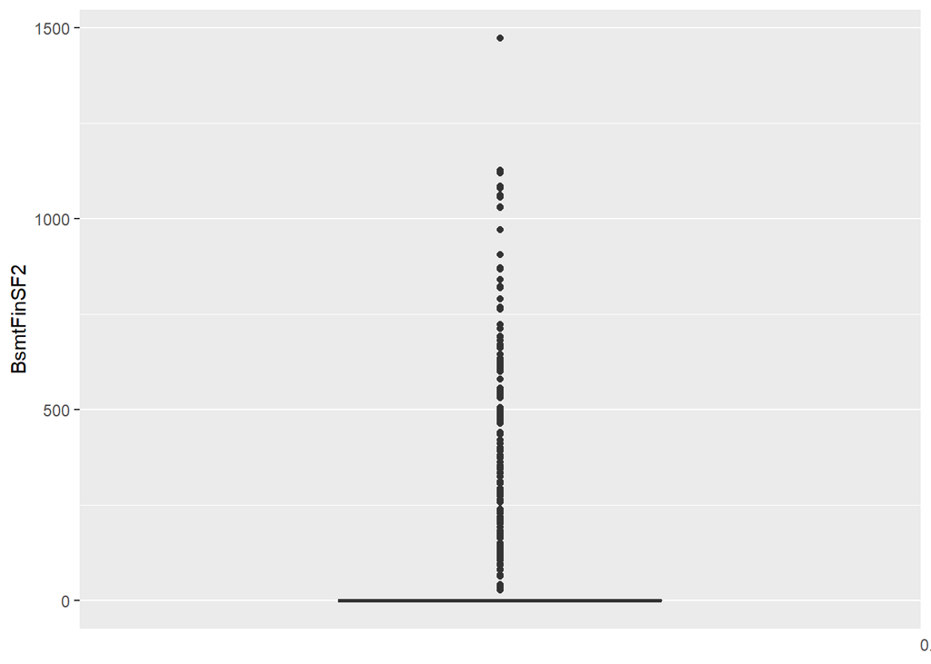

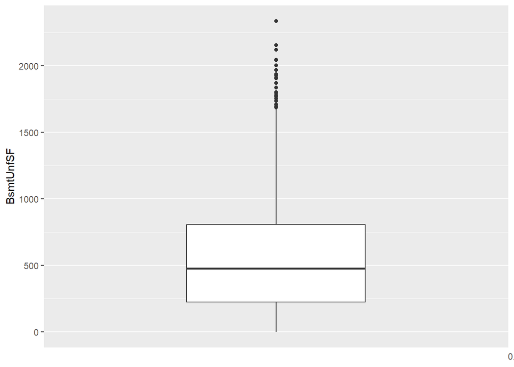

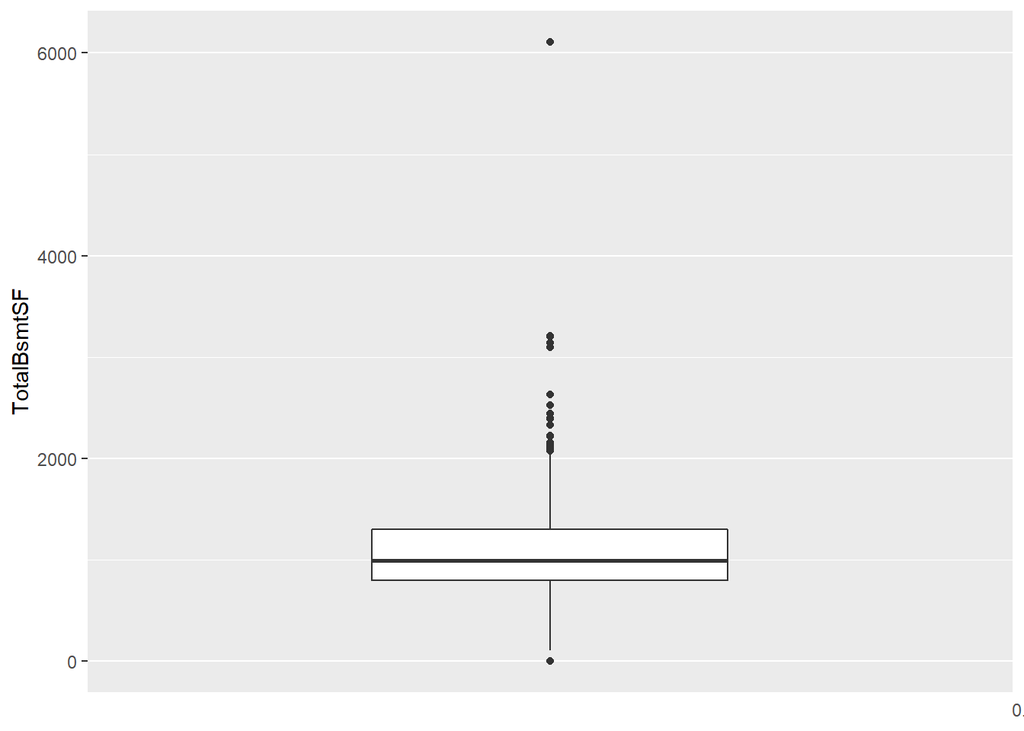

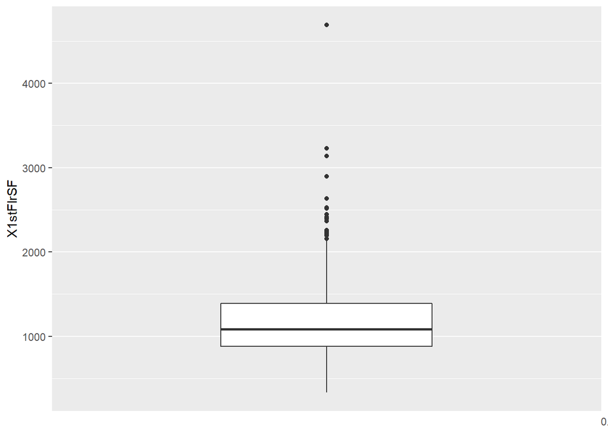

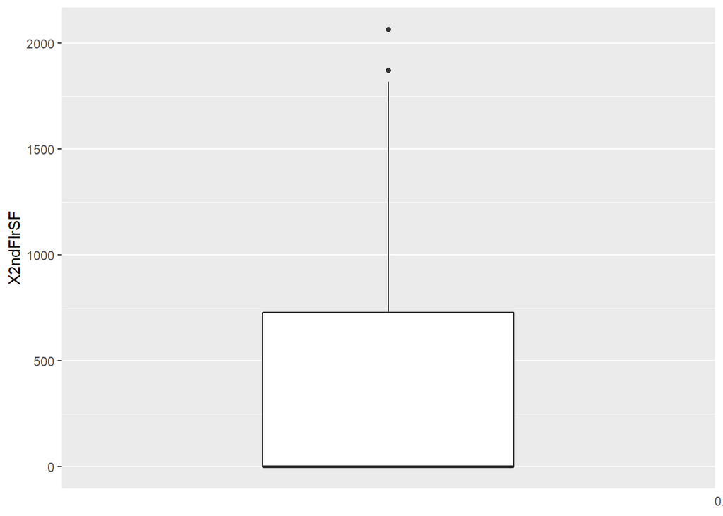

[20 more figures not shown]

```r
lapply(varlist, FUN = plot)
```

Display the outliers using boxplot.stats and by using the 5th and 95th percentile

```r
boxplot.stats(housing$Fireplaces)$out
```

```
## [1] 3 3 3 3 3
```

```r
select(housing,Fireplaces) %>% filter(Fireplaces > quantile(housing$Fireplaces, 0.05),Fireplaces > quantile(housing$Fireplaces, 0.95))
```

```
##   Fireplaces
## 1          3
## 2          3
## 3          3
## 4          3
## 5          3
```